# Exercise 1 (20 minutes)

You practice: APIs, joins, scatter plots, and the correlation coefficient — edge ② of our triangle. When you're done, assist some of the others …

1. Do the Setup, if you have not yet done so.
2. Start a new R script and copy in this starter code (it loads the packages and downloads both data sets — we walked through every line on the slides):

```r
pacman::p_load(
  tidyverse,    # Data manipulation & figures
  wbstats,      # World Bank data via API
  vdemdata,     # Varieties of Democracy data
  estimatr,     # OLS with robust standard errors
  modelsummary  # Nicely formatted regression tables
)

# V-Dem: civil liberties, and state ownership of the economy
Dat_vdem <- vdem %>%
  as_tibble() %>%
  select(country_text_id, year,
         civ_liberties = v2xcl_rol,    # Equality before the law & individual liberty
         state_own_raw   = v2clstown) %>% # State ownership of the economy
  mutate(state_ownership = -state_own_raw)  # Reverse: higher = MORE state ownership

# World Bank: extreme poverty (share below $3.00 a day, 2021 PPP).
# Try the live API; if it is down, fall back to the cached copy.
Dat_poverty <- wb_data("SI.POV.DDAY", start_date = 1972, end_date = 2025) %>%
  rename(poverty = SI.POV.DDAY,
         year = date,
         country_text_id = iso3c) %>%
  select(country_text_id, year, country, poverty) %>%
  drop_na(poverty) %>%
  group_by(country) %>%
  filter(year == max(year)) %>% # Keep the most recent estimate per country
  ungroup()
```

3. **Now write the join yourself:** combine `Dat_poverty` and `Dat_vdem` into one tibble called `Dat`. Think first: *which* join do you want, and *which variables form the key*?

We want only countries that appear in **both** tibbles (an *inner* join), and a country is identified by its ISO code *together with* the year.

```r
Dat <- inner_join(Dat_poverty, Dat_vdem, by = c("country_text_id", "year"))
```

> **Stuck?**
> - Did the `pacman::p_load(...)` line run without red error messages? If not, fix that first.
> - Strange results? Clear leftovers with a fresh start: *Session → Restart R*, then rerun your script from the top.
4. Make a scatter plot with poverty as outcome on the Y-axis and civil liberties as predictor on the X-axis. Ask it the four questions from the lecture: *direction, form, spread, outliers*.

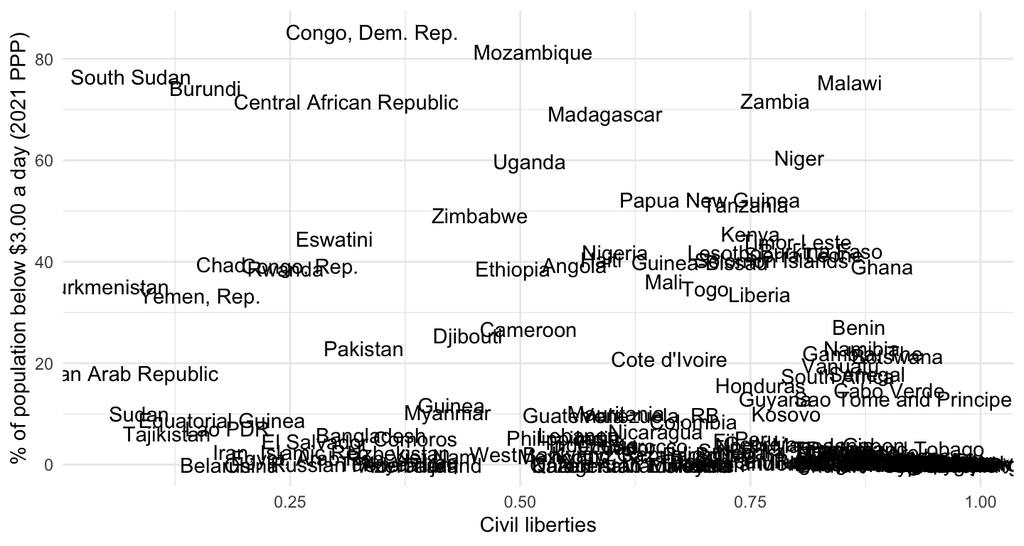

```r
ggplot(data = Dat, aes(y = poverty, x = civ_liberties)) +
  geom_text(aes(label = country)) +
  labs(y = "% of population below $3.00 a day (2021 PPP)",
       x = "Civil liberties") +
  theme_minimal()
```

5. **Before you compute anything:** judging only from your scatter plot, the correlation between poverty and civil liberties is …
6. Now check yourself: estimate the correlation with `cor()` (two digits are enough; point or comma is fine):

```r
Dat %>%
  select(poverty, civ_liberties) %>%
  cor()
#               poverty civ_liberties
# poverty          1.00         -0.33
# civ_liberties   -0.33          1.00
```

7. This is edge ② of our triangle. What does the correlation suggest about a liberty–equality trade-off?
8. **Write one sentence** in your R script (as a `# comment`) interpreting the correlation — as if for your term paper. Then compare with the model answer:

*Across 161 countries, civil liberties correlate moderately negatively with extreme poverty (r ≈ -0.33): countries with stronger civil liberties tend to have a smaller share of their population in extreme poverty.*

(Yours doesn't need the same words — but it should name the **direction**, the rough **strength**, and the **units of analysis** (countries), and it should *not* claim causality.)

**Bonus (for the fast):** `Dat` has 161 countries, but V-Dem covers 179 countries today. So the `inner_join()` silently dropped 18 of them. Before you open the answer: **which kinds of countries** do you think have no World Bank poverty estimate, and why?

The 18 lost countries have **no World Bank poverty estimate**, and for *two* different reasons. Some states do not run, or do not publish, the household surveys poverty figures are built from — **North Korea, Somalia, Eritrea, Cuba, Libya, Afghanistan**, several Gulf states. Others are simply too rich for the $3.00 line to be worth measuring — **New Zealand, Singapore, Hong Kong, Taiwan**. The join also loses 10 countries the other way round: small island states the World Bank surveys but V-Dem does not code.

Check the arithmetic: 161 kept + 18 lost = 179. An `inner_join()` dropped them **silently**. **Data that are missing are a finding, too:** our analysis can only speak about countries that measure poverty — which excludes both the least free and some of the richest.